# Statistical Learning HW4

Ding Zepeng,18307110088

2020/11/1

# Section 1: 证明题

## (1):

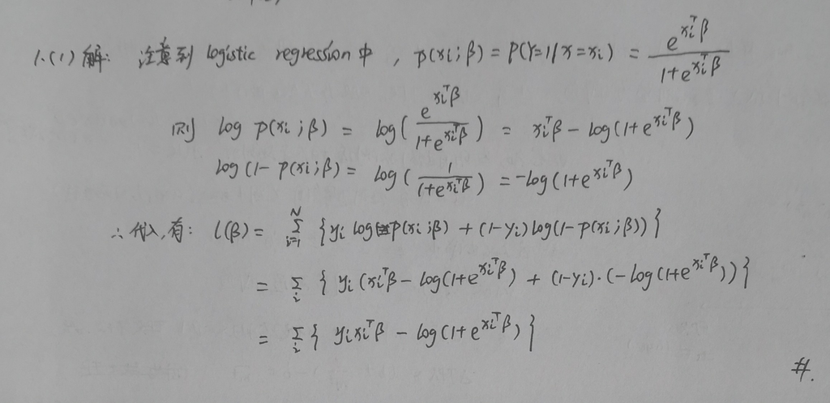

## (2):

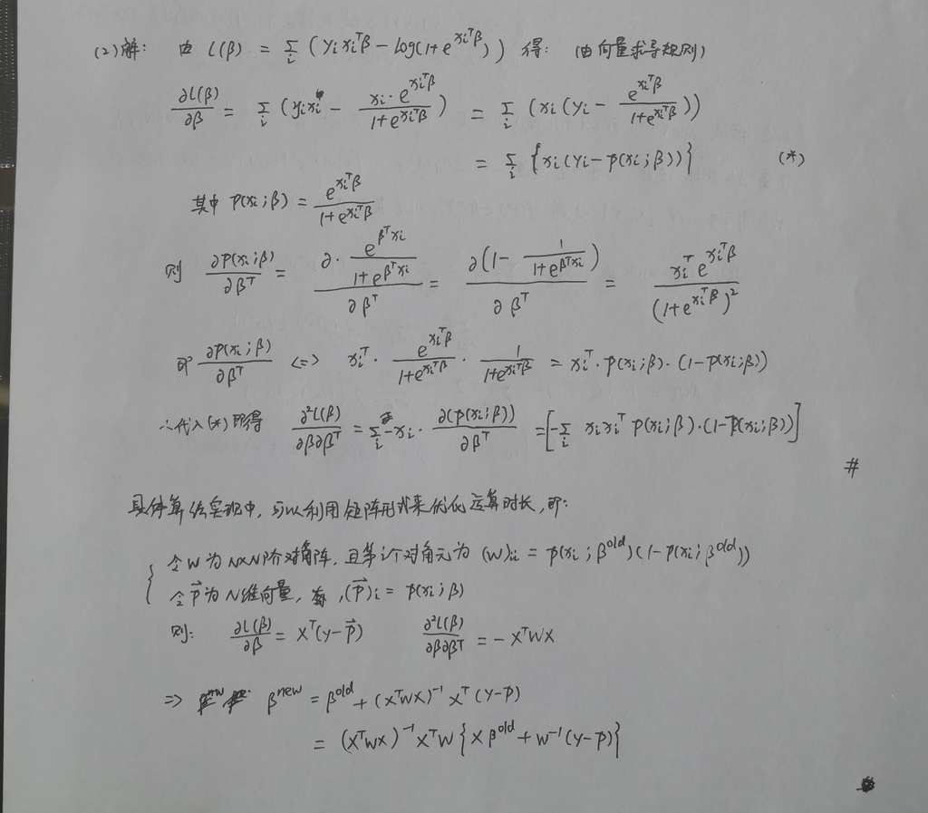

```r
# rm(list = ls())

# odds函数计算p(x_i,β)
odds <- function(x, beta){
  expo <- exp(x %*% beta)
  return(expo/(1+expo))
}

# 构建牛顿法的迭代函数, N为X1、X2维数，beta为给定的true parameter，R为估计的轮数
NRiter <- function(N, beta, R){
  best <- matrix(nrow = R,ncol = length(beta))   # 存储R轮的每次最大似然法估计出的值
  for(r in 1:R){
    ones <- rep(1, N)
    X1 <- rnorm(N)
    X2 <- rnorm(N)
    X <- matrix(c(ones, X1, X2), ncol = 3)
    y <- odds(X, beta)     # 构建因变量y,表示Y=1的概率值
    bold <- c(0,0,0)
    while(1){                # Newton-Raphson Algorithm ,矩阵形式
      pro <- odds(X, bold)
      W <- diag(c(pro*(1-pro)))
      Wi <- solve(t(X) %*% W %*% X)
      bnew <- bold + Wi %*% t(X) %*% (y - pro)
      if(max(abs(bnew-bold)) < 1e-5){break}
      bold <- bnew
    }
    best[r,] <- bold
  }
  return(best)
}

# 分别对N=200，500，800，1000进行系数估计
beta = c(0.5,1.2,-1)    # 真实的beta
# N=200
b1 <- NRiter(200,beta,200)
head(b1)
```

```
##           [,1]     [,2]       [,3]
## [1,] 0.4999968 1.199992 -0.9999933
## [2,] 0.5000000 1.200000 -1.0000000
## [3,] 0.5000000 1.200000 -1.0000000
## [4,] 0.5000000 1.200000 -1.0000000
## [5,] 0.5000000 1.200000 -1.0000000
## [6,] 0.5000000 1.200000 -1.0000000
```

```r
# N=500
b2 <- NRiter(500,beta,200)
head(b2)
```

```
##           [,1]     [,2]       [,3]
## [1,] 0.5000000 1.200000 -1.0000000
## [2,] 0.4999982 1.199994 -0.9999951
## [3,] 0.4999980 1.199995 -0.9999955
## [4,] 0.4999962 1.199990 -0.9999909
## [5,] 0.5000000 1.200000 -1.0000000
## [6,] 0.5000000 1.200000 -1.0000000
```

```r
# N=800
b3 <- NRiter(800,beta,200)
head(b3)
```

```
##           [,1]     [,2]       [,3]
## [1,] 0.5000000 1.200000 -1.0000000
## [2,] 0.4999984 1.199995 -0.9999961
## [3,] 0.4999976 1.199994 -0.9999946
## [4,] 0.4999989 1.199997 -0.9999972
## [5,] 0.4999985 1.199996 -0.9999971
## [6,] 0.4999991 1.199997 -0.9999977
```

```r
# N=1000
b4 <- NRiter(1000,beta,200)
head(b4)
```

```
##           [,1]     [,2]       [,3]
## [1,] 0.4999967 1.199992 -0.9999935
## [2,] 0.4999977 1.199995 -0.9999955
## [3,] 0.5000000 1.200000 -1.0000000
## [4,] 0.4999980 1.199995 -0.9999954
## [5,] 0.4999976 1.199994 -0.9999949
## [6,] 0.5000000 1.200000 -1.0000000
```

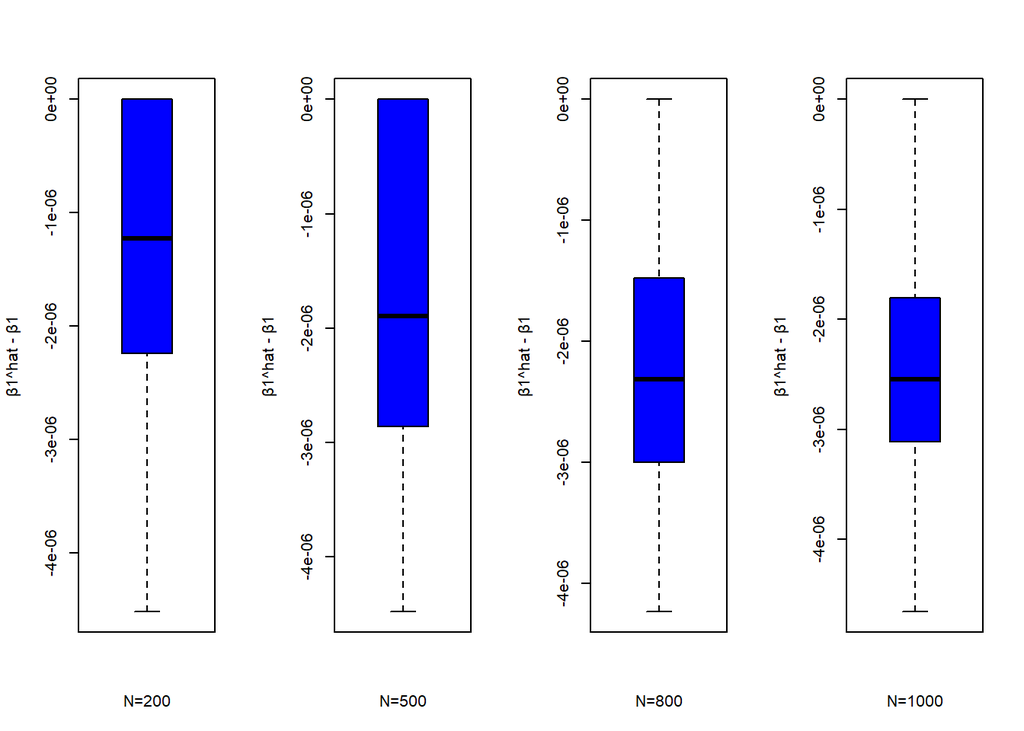

```r
# 对估计出的beta的各分量与真实值的差作箱线图，放到一起便于比较：
# beta_1
par(mfrow = c(1,4))
boxplot(b1[,1] - beta[1], ylab = "β1^hat - β1", xlab = "N=200", col = "blue")
boxplot(b2[,1] - beta[1], ylab = "β1^hat - β1", xlab = "N=500", col = "blue")
boxplot(b3[,1] - beta[1], ylab = "β1^hat - β1", xlab = "N=800", col = "blue")
boxplot(b4[,1] - beta[1], ylab = "β1^hat - β1", xlab = "N=1000", col = "blue")
```

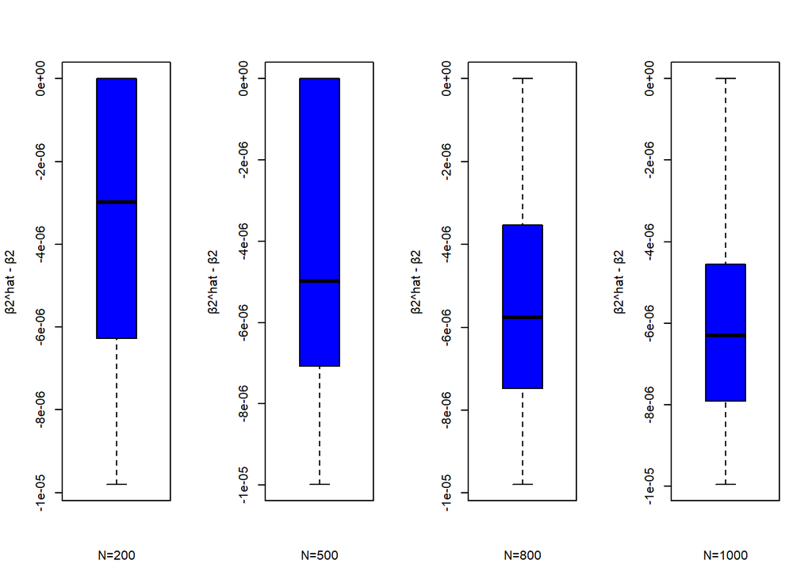

```r
# beta_2
par(mfrow = c(1,4))
boxplot(b1[,2] - beta[2], ylab = "β2^hat - β2", xlab = "N=200", col = "blue")
boxplot(b2[,2] - beta[2], ylab = "β2^hat - β2", xlab = "N=500", col = "blue")
boxplot(b3[,2] - beta[2], ylab = "β2^hat - β2", xlab = "N=800", col = "blue")
boxplot(b4[,2] - beta[2], ylab = "β2^hat - β2", xlab = "N=1000", col = "blue")
```

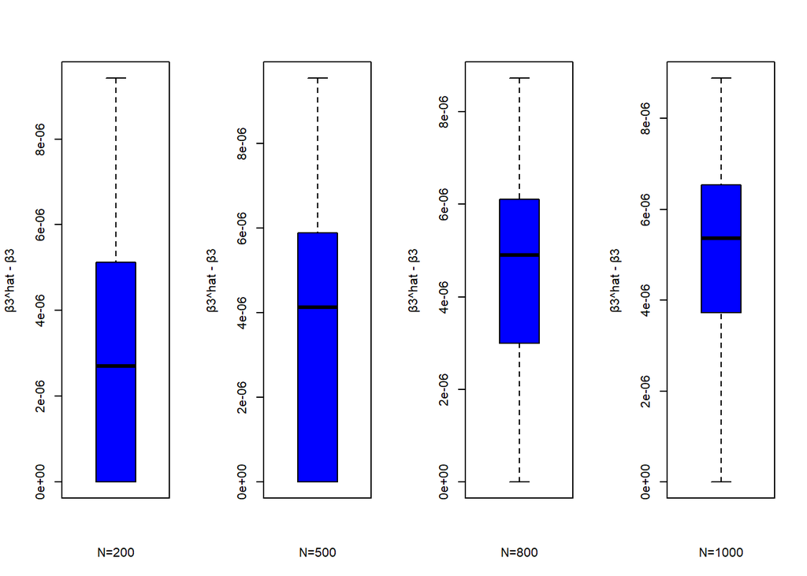

```r
# beta_3
par(mfrow = c(1,4))
boxplot(b1[,3] - beta[3], ylab = "β3^hat - β3", xlab = "N=200", col = "blue")
boxplot(b2[,3] - beta[3], ylab = "β3^hat - β3", xlab = "N=500", col = "blue")
boxplot(b3[,3] - beta[3], ylab = "β3^hat - β3", xlab = "N=800", col = "blue")
boxplot(b4[,3] - beta[3], ylab = "β3^hat - β3", xlab = "N=1000", col = "blue")
```

- 由结果可以看出，N越大，估计量本身的方差越小，即越稳定（体现在box纵向宽度变窄）
- [注]：beta的第三个分量是负值，而题目仅要求作差来衡量误差而并未要求取绝对值，所以其”箱线图趋势“与前两个分量相反

## (3):

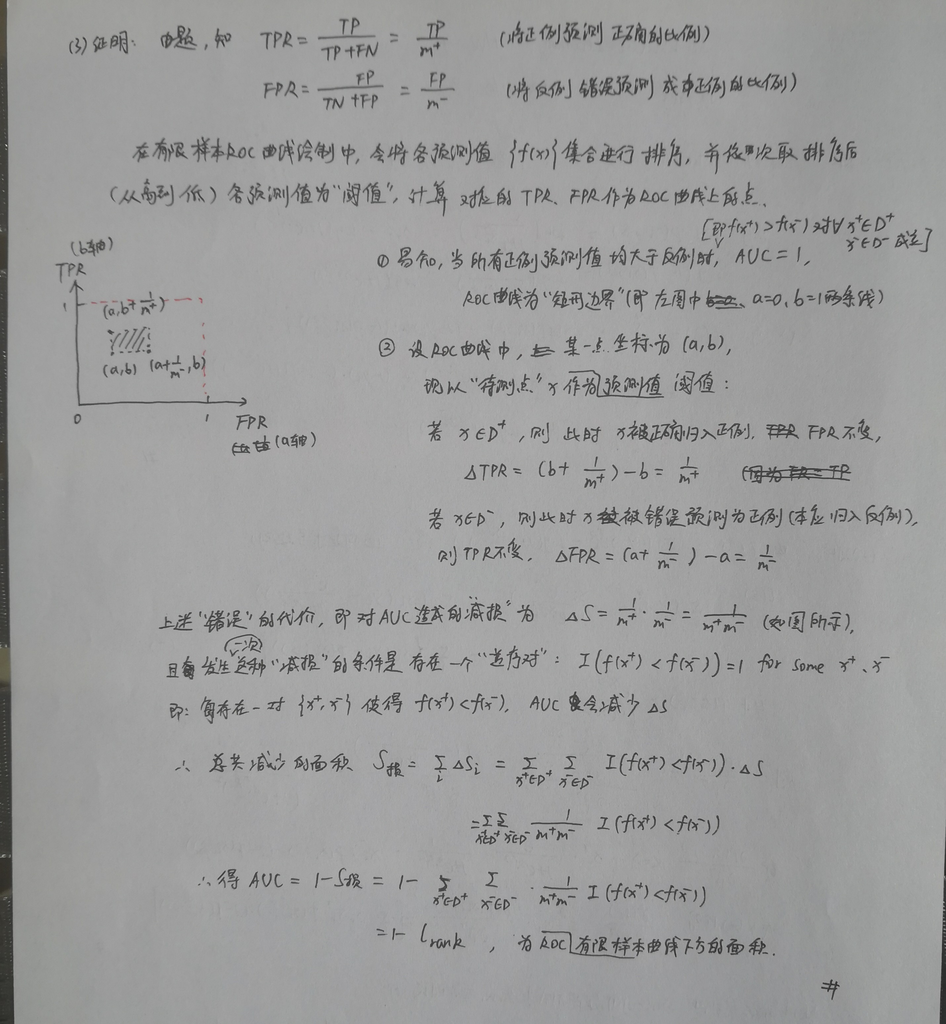

# Section 2: 客户流失预警分析

## 1. 读入训练数据及数据清洗

```r
Sdata <- read.csv("sampledata.csv", header = T)   # 读入CSV文件
# 使用subset函数筛选合理的数据;删去ID列
Sdata <- subset(Sdata[,2:9], (Sdata$expense>=0) & (Sdata$degree>=0) & (Sdata$tightness>=0) )
head(Sdata)
```

```
##     tenure   expense    degree tightness  entropy   chgexpense   chgdegree
## 1 3546.982  98.83939  59.38160  4.412337 2.891591 -0.001689189  0.20000000
## 2 3534.176  52.46216  52.63524  6.339493 2.374380 -0.515496521  0.13333333
## 3 3543.090  99.13804  83.98420  6.088656 3.483737 -0.008115049 -0.09677419
## 4 2191.264  79.24091  81.27537  9.308131 2.383951 -0.090180361 -0.09090909
## 5 2094.206 218.76704  88.39476  7.647743 3.706351 -0.068258664 -0.13461539
## 6 2098.417  93.90215 123.62474  5.586637 3.780796  0.033482143  0.43023256
##   churn
## 1     0
## 2     0
## 3     0
## 4     0
## 5     0
## 6     0
```

```r
summary(Sdata)   # 对数据进行总结
```

```
##      tenure          expense             degree            tightness
##  Min.   : 184.0   Min.   :  0.1784   Min.   :  0.04722   Min.   : 0.00486
##  1st Qu.: 537.1   1st Qu.: 98.2789   1st Qu.: 30.34109   1st Qu.: 5.41880
##  Median : 994.7   Median :136.0573   Median : 54.12898   Median : 8.03004
##  Mean   :1257.5   Mean   :161.2421   Mean   : 66.68942   Mean   : 9.86537
##  3rd Qu.:1635.9   3rd Qu.:204.0966   3rd Qu.: 89.85727   3rd Qu.:11.94831
##  Max.   :4479.6   Max.   :511.0550   Max.   :303.98270   Max.   :61.67615
##     entropy        chgexpense         chgdegree           churn
##  Min.   :0.000   Min.   :-1.00000   Min.   :-0.9964   Min.   :0.00000
##  1st Qu.:2.373   1st Qu.:-0.07634   1st Qu.:-0.1573   1st Qu.:0.00000
##  Median :2.990   Median : 0.00000   Median : 0.0000   Median :0.00000
##  Mean   :2.931   Mean   : 0.00762   Mean   : 0.0376   Mean   :0.01247
##  3rd Qu.:3.559   3rd Qu.: 0.04337   3rd Qu.: 0.1667   3rd Qu.:0.00000
##  Max.   :5.346   Max.   : 2.66502   Max.   : 7.3333   Max.   :1.00000
```

- 可以通过比较median和mean粗略判断自变量右偏程度

## 2. 绘制因变量与各自变量箱线图

- 因变量与各个自变量的箱线图如下所示：
- [注] 个体花费变化、个体度变化右偏，但存在负值，因此取绝对值后对数化（同时放上原箱线图以供对比）

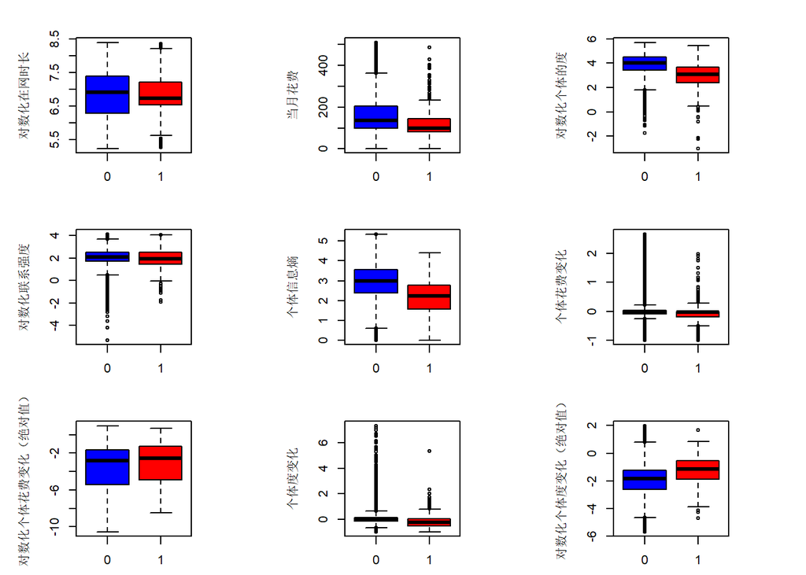

```r
par(mfrow = c(3,3),pin = c(1,1))
boxplot(log(Sdata$tenure) ~ Sdata$churn, ylab = "对数化在网时长", xlab = "是否流失", col = c("blue","red"))
boxplot(Sdata$expense ~ Sdata$churn, ylab = "当月花费", xlab = "是否流失", col = c("blue","red"))
boxplot(log(Sdata$degree) ~ Sdata$churn, ylab = "对数化个体的度", xlab = "是否流失", col = c("blue","red"))
boxplot(log(Sdata$tightness) ~ Sdata$churn, ylab = "对数化联系强度", xlab = "是否流失", col = c("blue","red"))
boxplot(Sdata$entropy ~ Sdata$churn, ylab = "个体信息熵", xlab = "是否流失", col = c("blue","red"))
boxplot(Sdata$chgexpense ~ Sdata$churn, ylab = "个体花费变化", xlab = "是否流失", col = c("blue","red"))
boxplot(log(abs(Sdata$chgexpense)) ~ Sdata$churn, ylab = "对数化个体花费变化（绝对值）", xlab = "是否流失", col = c("blue","red"))
boxplot(Sdata$chgdegree ~ Sdata$churn, ylab = "个体度变化", xlab = "是否流失", col = c("blue","red"))
boxplot(log(abs(Sdata$chgdegree)) ~ Sdata$churn, ylab = "对数化个体度变化（绝对值）", xlab = "是否流失", col = c("blue","red"))
```

+ 可以看到，流失用户的这七项指标与未流失用户的相应指标均有较为明显的差别

## 3. 对自变量进行标准化、建立逻辑回归模型

```r
## 用scale()函数进行自变量标准化
Sdata1 <- data.frame(scale(Sdata[,-8]))
Sdata1$churn <- Sdata$churn

## 建立逻辑回归模型
glm.fit1 <- glm(churn ~ ., data = Sdata1, family = binomial(link = "logit"))
summary(glm.fit1)
```

```
##
## Call:
## glm(formula = churn ~ ., family = binomial(link = "logit"), data = Sdata1)
##
## Deviance Residuals:
##     Min       1Q   Median       3Q      Max
## -0.8909  -0.1748  -0.1198  -0.0748   4.2072
##
## Coefficients:
##             Estimate Std. Error z value Pr(>|z|)
## (Intercept) -5.05338    0.07212 -70.067  < 2e-16 ***
## tenure      -0.24767    0.06070  -4.080 4.50e-05 ***
## expense     -0.29229    0.05904  -4.951 7.39e-07 ***
## degree      -0.73751    0.13172  -5.599 2.15e-08 ***
## tightness   -0.22660    0.04254  -5.327 9.99e-08 ***
## entropy     -0.35176    0.07208  -4.880 1.06e-06 ***
## chgexpense  -0.16071    0.04893  -3.284  0.00102 **
## chgdegree   -0.38279    0.05208  -7.349 1.99e-13 ***
## ---
## Signif. codes:  0 '***' 0.001 '**' 0.01 '*' 0.05 '.' 0.1 ' ' 1
##
## (Dispersion parameter for binomial family taken to be 1)
##
##     Null deviance: 6475.5  on 48284  degrees of freedom
## Residual deviance: 5757.6  on 48277  degrees of freedom
## AIC: 5773.6
##
## Number of Fisher Scoring iterations: 8
```

```r
library(knitr)
knitr::kable(summary(glm.fit1)$coef)      # 展示系数的估计结果
```

|  | Estimate | Std. Error | z value | Pr(>\|z\|) |
| --- | --- | --- | --- | --- |
| (Intercept) | -5.0533764 | 0.0721225 | -70.066599 | 0.0000000 |
| tenure | -0.2476730 | 0.0606981 | -4.080406 | 0.0000450 |
| expense | -0.2922921 | 0.0590377 | -4.950936 | 0.0000007 |
| degree | -0.7375089 | 0.1317160 | -5.599237 | 0.0000000 |
| tightness | -0.2265956 | 0.0425378 | -5.326922 | 0.0000001 |
| entropy | -0.3517571 | 0.0720835 | -4.879853 | 0.0000011 |
| chgexpense | -0.1607130 | 0.0489320 | -3.284418 | 0.0010219 |
| chgdegree | -0.3827941 | 0.0520849 | -7.349431 | 0.0000000 |

## 4. 对训练集和测试集进行预测

```r
## 对训练集进行预测
predict1.prob <- predict.glm(glm.fit1, type = "response", newdata = Sdata1)    # 预测流失概率
mean(predict1.prob)     # 查看预测的流失概率的均值
```

```
## [1] 0.01246764
```

```r
pre1 <- 1*(predict1.prob > mean(Sdata1$churn))   # 进行预测,类别严重不均衡因此以正反例之比作为阈值
table(Sdata1$churn, pre1)    # 打印confusion matrix
```

```
##    pre1
##         0     1
##   0 32591 15092
##   1   171   431
```

```r
## 对测试集进行预测
# 读入测试集数据并清洗
Pdata <- read.csv("preddata.csv", header = T)
# 使用subset函数筛选合理的数据;删去ID列
Pdata <- subset(Pdata[,2:9], (Pdata$expense>=0) & (Pdata$degree>=0) & (Pdata$tightness>=0) )

Pdata1 <- data.frame(scale(Pdata[,-8]))     # 进行自变量标准化
Pdata1$churn <- Pdata$churn

predict2.prob <- predict.glm(glm.fit1, type = "response", newdata = Pdata1)    # 预测流失概率
mean(predict2.prob)     # 查看预测的流失概率的均值
```

```
## [1] 0.01253698
```

```r
pre2 <- 1*(predict2.prob > mean(Pdata1$churn))    # 进行预测,类别严重不均衡因此以正反例之比作为阈值
table(Pdata1$churn, pre2)    # 打印confusion matrix
```

```
##    pre2
##         0     1
##   0 33843 13268
##   1   201   459
```

## 5. 模型评价（绘制训练集、测试集上的ROC曲线、计算AUC值）

- 使用R包pROC绘制ROC曲线、计算AUC值

```r
library(pROC)
roc1 <- roc(Sdata1$churn,predict1.prob)  # 构建roc对象
roc2 <- roc(Pdata1$churn,predict2.prob)
```

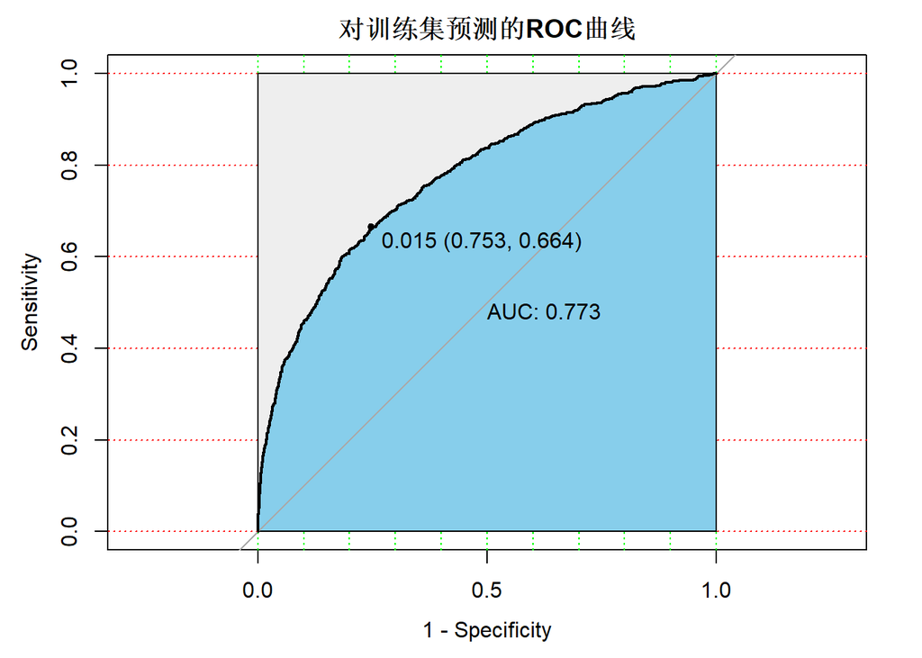

```r
plot(roc1, print.auc=TRUE, main="对训练集预测的ROC曲线", auc.polygon=TRUE, grid=c(0.1, 0.2),
     grid.col=c("green", "red"), max.auc.polygon=TRUE,
     auc.polygon.col="skyblue", print.thres=TRUE, legacy.axes = T)        #画出ROC曲线，标出坐标，并标出AUC的值
```

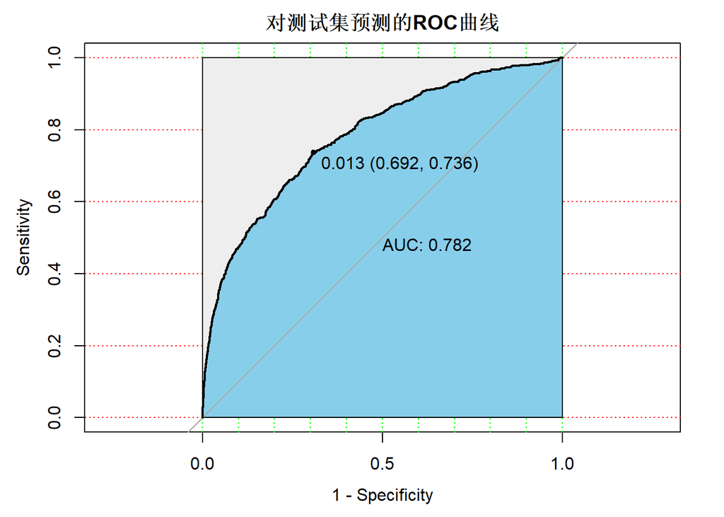

```r
plot(roc2, print.auc=TRUE, main="对测试集预测的ROC曲线", auc.polygon=TRUE, grid=c(0.1, 0.2),
     grid.col=c("green", "red"), max.auc.polygon=TRUE,
     auc.polygon.col="skyblue", print.thres=TRUE, legacy.axes = T)
```

- 模型评价：两条ROC曲线对应的AUC值都高于0.5（随机预测时的AUC值），说明模型的预测一定程度上是有效的，即能将大部分正例的概率预测值排在反例之前——ROC曲线和AUC值与阈值设置并无关系，主要衡量模型分类器的“将正例预测值排序在反例之前的能力”，因此从这个意义上而言本逻辑回归模型的分类效果较不错。 但无论是在训练集还是在测试集上进行预测，AUC值均约0.77~0.79，接近于1但“又没那么接近”，且由上一小节的confusion matrix可以得知，尽管“真正的正例（流失）大多数都被预测成了正例”，但也有大量的反例（不流失）被预测成正例——这与样本类别严重不均衡也有一定的关系。总的来说，该逻辑回归模型的分类能力“效果不错（not bad）”，但也“并不特别好（not pretty）”。